# Homework Week 47: Homicides in western Europe

Freja Skall Thorøe

30/11/2021 updated: 01 december, 2021

This exercise is based on the dataset provided by [OurWorldInData project](https://ourworldindata.org/homicides) based at the Oxford University.

### The long-term trend in Homicides in Western Europe

Understanding how homicide rates have changed prior to the modern era requires the help of historians and archivists. Manuel Eisner, a criminology professor at the University of Cambridge, and his colleagues published the Historical Violence Database a compilation of data on long-term trends in homicide rates, in addition to qualitative information such as the cause of death, perpetrator and victim. This database is limited to countries with relatively complete historical records on violence and crime – mainly Western Europe and the US.

Starting in the second half of the nineteenth century, these European regions have consistent police records of those accused of murder or manslaughter and annual counts of homicide victims. To go back further in time, reaching as far back as the thirteenth century, Eisner collected estimates (from historical records of coroner reports, court trials, and the police) of homicide rates made in over ninety publications by scholars.5

In the chart shown here we see long-run homicide rates for the five European regions.

Homicide rates – measured as the number of homicides per 100,000 individuals – up to 1990 are sourced from Eisner’s (2003) publication and the Historical Violence Database. These estimates have been combined, from 1990 onwards, with homicide rates from the Global Burden of Disease study.6

In the 1300s, homicide rates in Western Europe ranged from 23 to 56 homicides per 100,000 individuals, comparable to the current rates in Latin America. Homicide rates then fell dramatically in all five regions from the 1300s to 1800s. The magnitude of this decline was similar across countries: homicide rates fell between 78 and 98%.

Homicide rates in Europe today are much lower than in the past. England, Germany, Switzerland, and Italy reached their lowest levels in the 2000s; while the Netherlands, Belgium, and Scandinavia reached their minimums in the mid to late 1900s.

Additional notes about this paper: This paper only contains codes and answers to the questions in the EuropeanHomicide.RMD file.

```r
library(tidyverse)
Western_Europe <- read_csv("data/homicide-rates-across-western-europe.csv")
```

## Task 1) Renaming the column

the column name Western_Europe$`Homicide rate in Europe over long-term (per 100,000) is not very easy to work with. Relabel it to ‘homicides_per_100k’ inside R after loading the dataset and then edit all the ggplots.

```r
Western_Europe <- rename(Western_Europe, homicides_per_100k = `Homicide rate in Europe over long-term (per 100,000) (homicides per 100,000 people)`)
```

## Task 2) Facetplotting

The basic plot and following facet-plot (combination plot) is great, but geom_point - a scatterplot - is not the best choice for showing long-term data. Can you change both plots to more suitable type of rendering?

Trying out new ggplot functions to find out which is better for showing the long-term data.

Using geom_line. Quite good at showing the long-term data. Top Using geom_smooth. shows the data in a smoother way, that is more soothing on the eye, and gives a more quick sight to analyze.

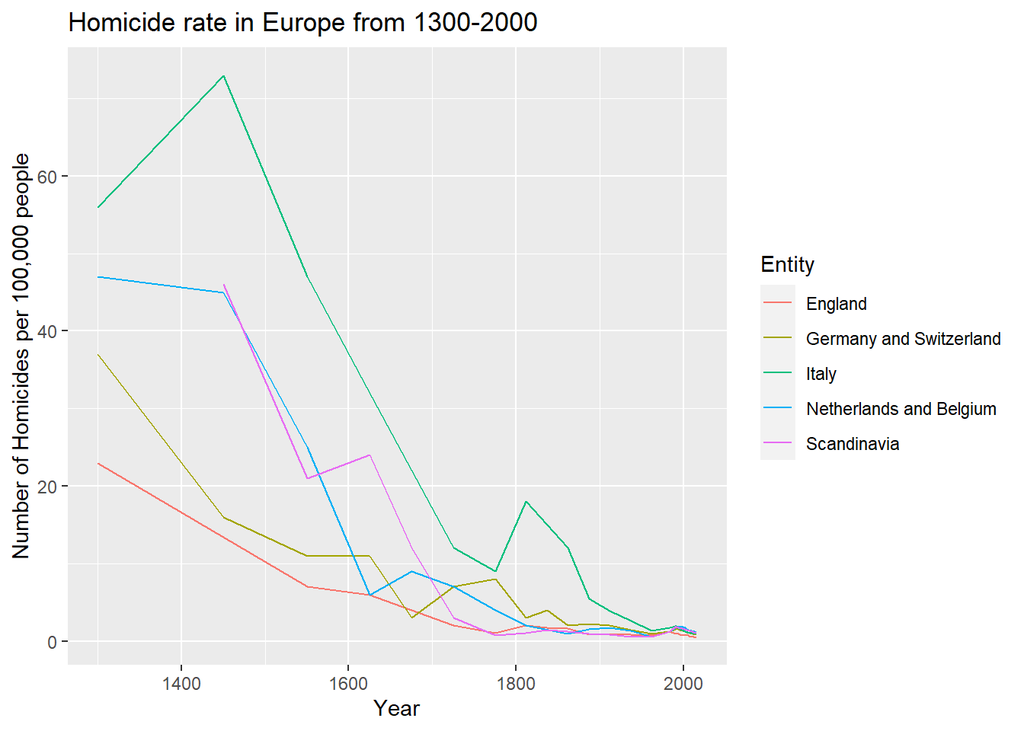

```r
ggplot(data = Western_Europe) +
  geom_line(mapping = aes(x = Year,
                           y = homicides_per_100k,
                           color = Entity)) +
  labs(x = "Year",
       y = "Number of Homicides per 100,000 people",
       title = "Homicide rate in Europe from 1300-2000")
```

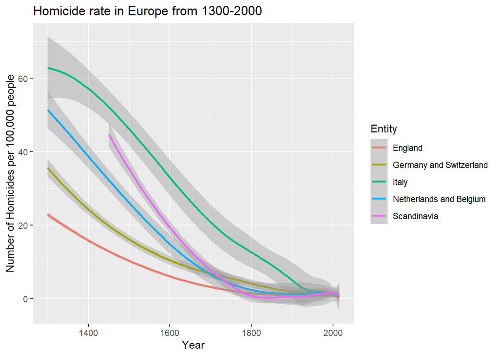

```r
ggplot(data = Western_Europe) +
  geom_smooth(mapping = aes(x = Year,
                           y = Western_Europe$homicides_per_100k,
                           color = Entity)) +
  labs(x = "Year",
       y = "Number of Homicides per 100,000 people",
       title = "Homicide rate in Europe from 1300-2000")
```

## Task 3) Change the layout of the plot

Can you change the facet “layout” to two columns and three rows so that the trends are easier to see?

By writing nrow and ncol you can change the layout of the facet and this code splits the plots into 5 instead of one. And in that way you can change the layout of the visualization.

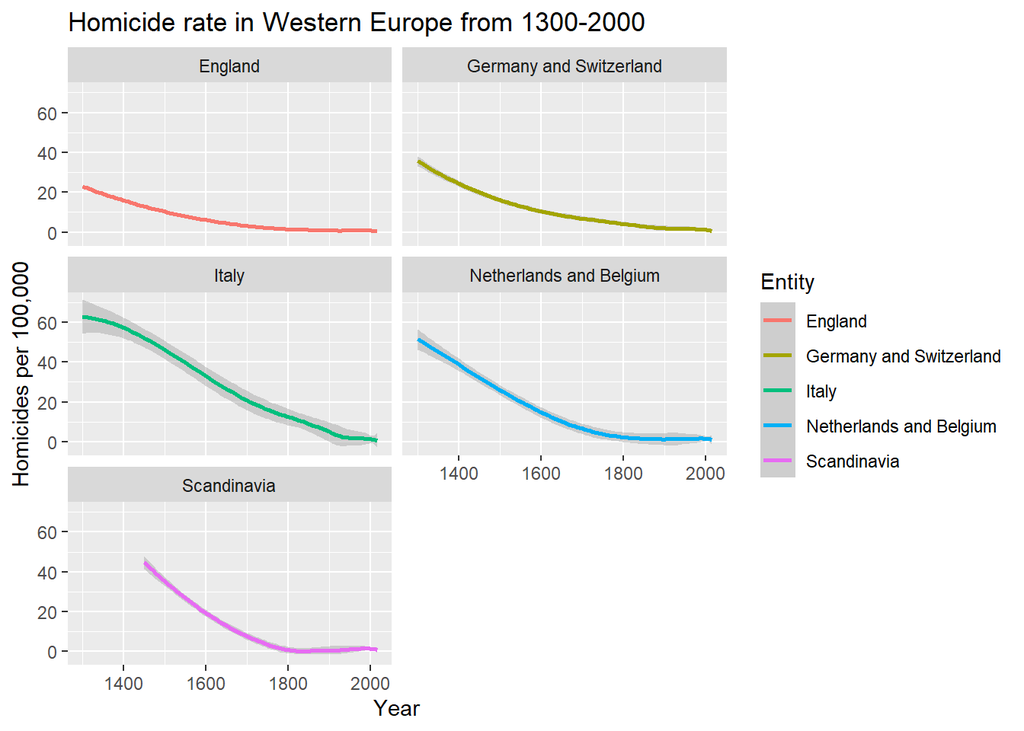

```r
ggplot(data = Western_Europe) +
  geom_smooth(mapping = aes(x = Year,
                           y = Western_Europe$homicides_per_100k,
                           color = Entity)) +
  facet_wrap(~ Entity, nrow =3,ncol = 2) +
  labs(x = "Year",
       y = "Homicides per 100,000",
       title = "Homicide rate in Western Europe from 1300-2000")
```

## Task 4) Moving the legend

Move the legend from the current position on the side to below the facets, and label it “Country” instead of “Entity”.

First i rename the legend, then i move the legends position to “bottom”.

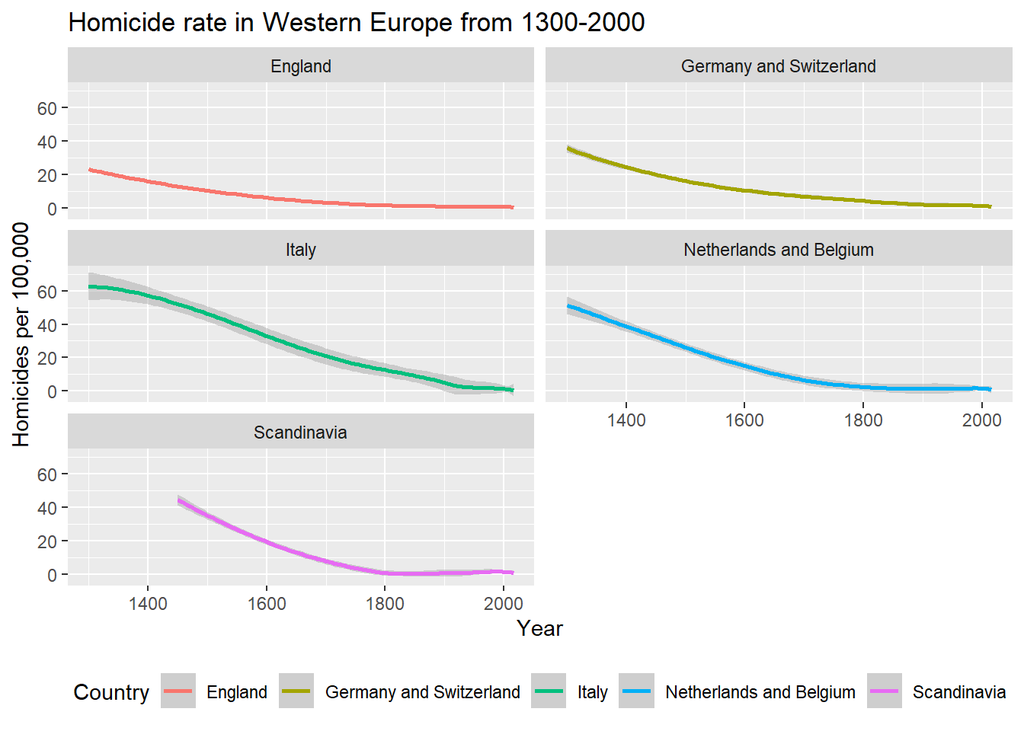

```r
Western_Europe2 <- rename(Western_Europe, Country = 'Entity')

ggplot(data = Western_Europe2) +
  geom_smooth(mapping = aes(x = Year,
                           y = Western_Europe$homicides_per_100k,
                           color = Country)) +
  theme(legend.position = "bottom")+
  facet_wrap(~ Country, nrow =3,ncol = 2) +
  labs(x = "Year",
       y = "Homicides per 100,000",
       title = "Homicide rate in Western Europe from 1300-2000")
```

## Task 5) Adding a floating table of contents

Add a floating table of contents to your Rmarkdown document, provide informative chunk-names to all your R chunks, and automatically generate a timestamp to show when the document was last updated. (Hint: check the Rmarkdown episode in our Data Carpentry tutorial)

## Task 6) Emptying the code chunk

Fill in the empty code chunk with a ggplot of your Danish kings: loading the data, calculating the mid-year, and plotting the duration of reign (y axis) over the mid-year (x axis), using geom_smooth()

Loading the data:

```r
danish_monarchs <- read_csv2("The_Danish_Monarchs_Tidy_version2.csv")
```

```
## i Using "','" as decimal and "'.'" as grouping mark. Use `read_delim()` for more control.
```

```
## * `` -> ...11
```

Checking the data if NA is recognized:

```r
head(danish_monarchs)
```

```
## # A tibble: 6 x 11
##   Name   Date_of_birth Month_of_birth Year_of_birth Date_of_death Month_of_death
##   <chr>          <dbl>          <dbl>         <dbl>         <dbl>          <dbl>
## 1 Gorm_~            NA             NA            NA            NA             NA
## 2 Haral~            NA             NA            NA            NA             NA
## 3 Svend~            NA             NA            NA            NA             NA
## 4 Haral~            NA             NA            NA            NA             NA
## 5 Knud_~            NA             NA           995            NA             NA
## 6 Harde~            NA             NA          1020            NA             NA
## # ... with 5 more variables: Year_of_death <dbl>, Reign_start <dbl>,
## #   Reign_end <dbl>, Years_of_reign <dbl>, ...11 <lgl>
```

Calculating the mid-year and The duration of reign (y-axis) over the mid-year (x-axis), using geom_smooth()

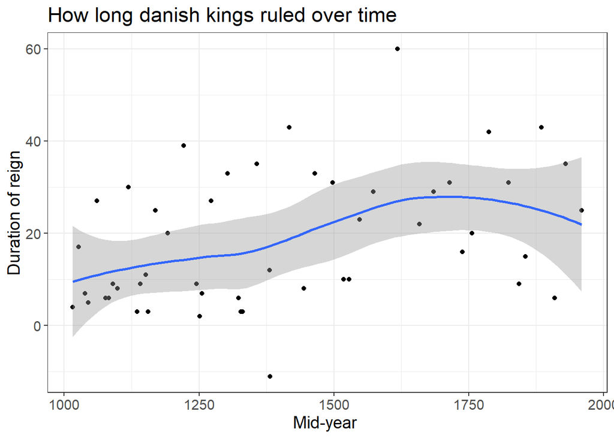

```r
danish_monarchs2 <- danish_monarchs %>%
  mutate(midyear = Reign_end -(Reign_end-Reign_start)/2)
ggplot(danish_monarchs2, aes(x = midyear, y = Years_of_reign)) +
  geom_point()+
  geom_smooth()+
  labs(title = "How long danish kings ruled over time",
       x = "Mid-year ", y = "Duration of reign") +
  theme_bw() +
  theme(text = element_text(size = 14))
```

The visualisation shows that the duration of reign in general became longer after 1600 and 1700. This becomes clear with the smooth line that shows the general pattern as opposed to the black dots that show the individual case of the monarch rule.

## Task 7) Opinion on the basis of data visualisations

Comment briefly what is your opinion on the basis of the data visualizations: are we more civilized today?

The homicide rate has dropped noticeably since the 1300s, and in the last 200-300 hundred years it has since 1700 the rate is closer to 0, compared to the rate between 20 and 60 in the 1300s. All this becomes very clear in the visualizations. If one is measuring whether we are more civilized on the basis of homicide rates, then we have in fact become more civilized.